# Principios de Estadística Aplicada con R

Pruebas de hipótesis

Gabriel Carrasco Escobar

Universidad Peruana Cayetano Heredia

Jorge Ruiz Cabrejos

Universidad Peruana Cayetano Heredia

19 de febrero del 2018

Rutinas y comandos complementarios del curso *Principios de Estadística Aplicada con R (PEAR)*

*Cualquier problema con este código, porfavor contactar a gabriel.carrasco@upch.pe*

Los paquetes que se utilizaran son:

```r
library(dplyr)
library(epiDisplay)
```

Los ejercicios a continuación utilizan la base de datos `Winzell2004_covar_v2.csv`, a la que colocaremos de nombre `dat`.

```r
dat <- read.csv("C:/Usuario/Estudiante/Escritorio/Estadistica/Winzell2004_covar_v2.csv")
```

## Pruebas de hipótesis paramétricas

### Diferencia de medias - Prueba T-Test

La prueba de t-test se utiliza para comparar variables continuas en dos grupos. La variable dependiente numerica tiene que tener **distribución normal**.

En este caso, los grupos de comparación estan en la variable `Diet` (dieta `chow` y dieta `hf`. Asumiremos que nuestra variable numérica, peso, tiene distribución normal.

**Nota:[Revisar el análisis de dsitribución normal](https://gcarrascoe.github.io/class/PEAR_2.html)**

Nuestra base de datos `Dat` contiene la información de la población. Para fines de esta práctica, seleccionaremos una muestra de 200 ratones utilizando la función `sample_n` para seleccionar una muestra.

```r
sample<-sample_n(dat,200)
```

Utilizamos `var.test` para determinar si existe homogeneidad de varianzas.

```r
var.test(sample$Bodyweight~sample$Diet)
```

```
##
##  F test to compare two variances
##
## data:  sample$Bodyweight by sample$Diet
## F = 0.50152, num df = 108, denom df = 89, p-value = 0.000648
## alternative hypothesis: true ratio of variances is not equal to 1
## 95 percent confidence interval:
##  0.3351566 0.7446518
## sample estimates:
## ratio of variances
##          0.5015207
```

El resultado de nuestro interés es el `p-value` o valor de p.

- Hipotesis nula (H0): Varianzas iguales
- Hipotesis Alternativa (Ha): Varianzas diferentes

Si `p-value` es **menor** a 0.05, se considera significativo y se rechaza la hipótesis nula. Es decir, se concluye que las varianzas son diferentes.

Si `p-value` es **mayor** a 0.05, se considera no significativo y no se rechaza la hipótesis nula. Es decir, se concluye que las varianzas son iguales

**NOTA:** El valor de p puede dar como resultado un valor como: `p-value = 1.92e-07`.

Esto ocurre debido a que 1.92e-07 es la notación científica para 0.000000192. Es decir, p es menor a 0.05.

### Varianzas diferentes - Test de Welch

Para nuestro caso, al ser las varianzas diferentes utilizamos el test de Welch con la función `t.test`.

Las variables a comparar son `sample$Bodyweight` y `sample$Diet`.

Colocamos `var.equal = FALSE` al ser las varianzas diferentes.

```r
t.test(sample$Bodyweight~sample$Diet,var.equal = FALSE, paired=FALSE)
```

```
##
##  Welch Two Sample t-test
##
## data:  sample$Bodyweight by sample$Diet
## t = -3.5714, df = 155.94, p-value = 0.0004725
## alternative hypothesis: true difference in means is not equal to 0
## 95 percent confidence interval:
##  -5.219351 -1.501905
## sample estimates:
## mean in group chow   mean in group hf
##           27.33982           30.70044
```

Utilizamos el resultado de `p-value` para determinar si existe una diferencia estadisticamente significativa.

- Hipotesis nula (H0): La diferencia de medias es igual a 0
- Hipotesis Alternativa (Ha): La diferencia de medias no es igual a 0

Si `p-value` es **menor** a 0.05, se considera significativo y se rechaza la hipótesis nula. Es decir, se concluye que las medias son estadisticamente diferentes entre los grupos.

Si `p-value` es **mayor** a 0.05, se considera no significativo y no se rechaza la hipótesis nula. Es decir, se concluye que las medias no son estadisticamente diferentes entre los grupos.

### Varianzas iguales - Test de Student

En el caso de tener varianzas iguales (un p>0.05 al utilizar `var.test`), utilizamos el test de student.

Las variables a comparar son `sample$Bodyweight` y `sample$Diet`.

Al ser las varianzas iguales, colocamos `var.equal = TRUE`.

```r
t.test(sample$Bodyweight~sample$Diet,var.equal = TRUE, paired= FALSE)
```

```
##
##  Two Sample t-test
##
## data:  sample$Bodyweight by sample$Diet
## t = -3.6871, df = 197, p-value = 0.0002933
## alternative hypothesis: true difference in means is not equal to 0
## 95 percent confidence interval:
##  -5.158111 -1.563145
## sample estimates:
## mean in group chow   mean in group hf
##           27.33982           30.70044
```

Utilizamos el resultado de `p-value` para determinar si existe una diferencia estadisticamente significativa.

- Hipotesis nula (H0): La diferencia de medias es igual a 0
- Hipotesis Alternativa (Ha): La diferencia de medias no es igual a 0

Si `p-value` es **menor** a 0.05, se considera significativo y se rechaza la hipótesis nula. Es decir, se concluye que las medias son estadisticamente diferentes entre los grupos.

Si `p-value` es **mayor** a 0.05, se considera no significativo y no se rechaza la hipótesis nula. Es decir, se concluye que las medias no son estadisticamente diferentes entre los grupos.

## Pruebas de hipótesis no paramétricas

### Prueba de Mann-Whitney

La prueba de Mann-Whitney se utiliza para comparar variables continuas en dos grupos. La variable dependiente numerica tiene que tener **distribución no normal**.

Para el siguiente caso, utilizamos las categorias de sexo `M` y `F`. Nuestra variable numérica sera `en_intake`, la cual tiene una distribución no normal:

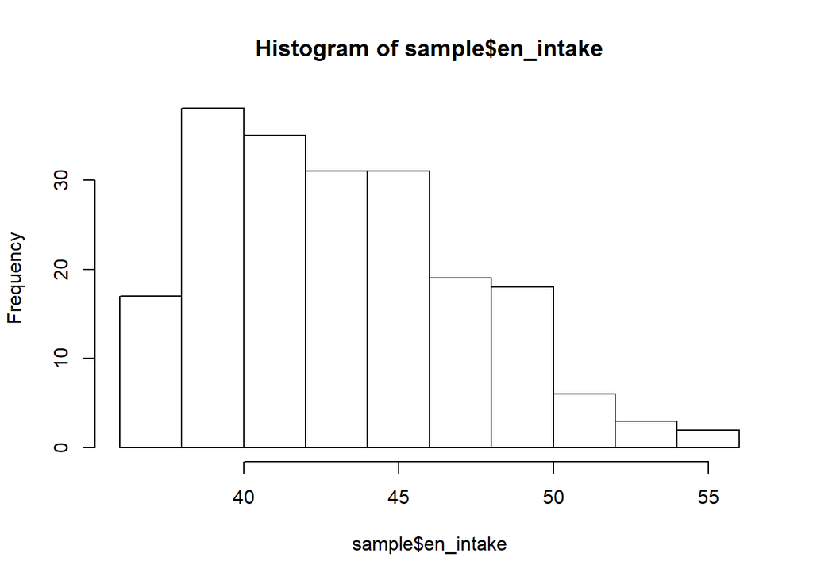

```r
hist(sample$en_intake)
```

La prueba de Mann-Whitney **no compara medianas**; determina si una variable tiene valores más altos (localización entre grupos).

La función que se utiliza para realizar el test es `wilcox.test`

```r
wilcox.test(en_intake~Sex,data=sample)
```

```
##
##  Wilcoxon rank sum test with continuity correction
##
## data:  en_intake by Sex
## W = 5273, p-value = 0.4857
## alternative hypothesis: true location shift is not equal to 0
```

Utilizamos el resultado de `p-value` para determinar si existe una diferencia estadisticamente significativa.

- Hipotesis nula (H0): Las poblaciones tienen localizaciones iguales
- Hipotesis Alternativa (Ha): Las poblaciones difieren con respecto a la localización

Si `p-value` es **menor** a 0.05, se considera significativo y se rechaza la hipótesis nula. Es decir, se concluye que las localizaciones (valores) son estadisticamente diferentes entre los grupos.

Si `p-value` es **mayor** a 0.05, se considera no significativo y no se rechaza la hipótesis nula. Es decir, se concluye que las localizaciones (valores) no son estadisticamente diferentes entre los grupos.

### Prueba Fisher Exact

El test de Fisher Exact es una prueba de independencia para una tabla de contingencia comparando dos variables categóricas.

Para el siguiente caso, comparamos las categorias de dieta (`chow` y `hf`) con sexo (`M` y `F`).

La función utiliza una tabla para el análisis. Por lo que primero pasaremos nuestros datos de `Diet` y `Sex` a un objeto tabla con `table`.

```r
tabla_fisher<-table(sample$Diet,sample$Sex)
tabla_fisher
```

```
##
##         F  M
##   chow 53 57
##   hf   42 48
```

Utilizamos la función `fisher.test` con el objeto tabla creado para obtener nuestro resultado.

```r
fisher.test(tabla_fisher)
```

```
##
##  Fisher's Exact Test for Count Data
##
## data:  tabla_fisher
## p-value = 0.8872
## alternative hypothesis: true odds ratio is not equal to 1
## 95 percent confidence interval:
##  0.585761 1.929115
## sample estimates:
## odds ratio
##   1.062314
```

Utilizamos `p-value` para determinar si existe una diferencia estadisticamente significativa.

- Hipotesis nula (H0): Las variables son independientes
- Hipotesis Alternativa (Ha): Las variables no son independientes

Si `p-value` es **menor** a 0.05, se considera significativo y se rechaza la hipótesis nula. Es decir, se concluye que sexo y dieta están asociados de forma significativa.

Si `p-value` es **mayor** a 0.05, se considera no significativo y no se rechaza la hipótesis nula. Es decir, se concluye que sexo y dieta no están asociados de forma significativa.

### Prueba X² de Pearson

La prueba X² de Pearson se utiliza para comparar variables categóricas.

Para el siguiente caso, compararemos las categorias de dieta (`chow` y `hf`) con sexo (`M` y `F`).

La función utiliza una tabla para el análisis. Por lo que primero pasaremos nuestros datos de `Diet` y `Sex` a un objeto tabla con `table`.

```r
tabla_chi<-table(sample$Diet,sample$Sex)
tabla_chi
```

```
##
##         F  M
##   chow 53 57
##   hf   42 48
```

Utilizamos la función `chisq.test` con el objeto tabla creado para obtener nuestro resultado.

```r
chisq.test(tabla_chi)
```

```
##
##  Pearson's Chi-squared test with Yates' continuity correction
##
## data:  tabla_chi
## X-squared = 0.0050632, df = 1, p-value = 0.9433
```

Utilizamos `p-value` para determinar si existe una diferencia estadisticamente significativa.

- Hipotesis nula (H0): Las variables son independientes
- Hipotesis Alternativa (Ha): Las variables no son independientes

Si `p-value` es **menor** a 0.05, se considera significativo y se rechaza la hipótesis nula. Es decir, se concluye que sexo y dieta están asociados de forma significativa.

Si `p-value` es **mayor** a 0.05, se considera no significativo y no se rechaza la hipótesis nula. Es decir, se concluye que sexo y dieta no están asociados de forma significativa.